# EDRM 718 Project A-Gun Deaths

Hui Jiang

January 30 2021

### Description

This report will study the compositions of the intents of gun deaths and individual attributes in American in 2012. The data for this study is primarily from the Centers for Disease COntrol ans Prevention’s Multiple Cause of Death database provided by Ben Casselman, et al. First, I will study the compositions of gun death types in the sample. I will then examine the proportions of different groups in terms of individual attributes.

*Source of data: Centers for Disease COntrol ans Prevention’s Multiple Cause of Death database*

### Analysis

In this data set, there are four types of gun death: accidental, homicide, suicide, undetermined. Figure 1 illustrates the composition of the gun death types in 2012.

*Figure 1. Bar plots with proportions of gun death types in 2012.*

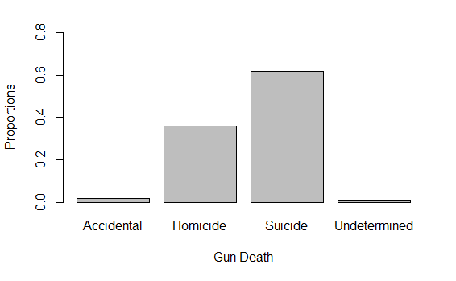

Table 1 shows the frequencies and percents for four types of gun death. The sample consists of 2% in the accidental death, 36% in the homicide, 62% in the suicide, and 1% in the undetermined death. Suicide is the most common type in these four types.

*Table 1. Frequencies and percents for each type of gun death in 2012.*

```
             death_counts_2012 death_props_2012
Accidental                 548             0.02
Homicide                 12093             0.36
Suicide                  20666             0.62
Undetermined               256             0.01
```

Figure 2 illustrates the composition of the gender types in gun death in 2012. From this figure, it is apparent that there are much more males than females.

*Figure 2. Bar plots with proportions of gender types in 2012.*

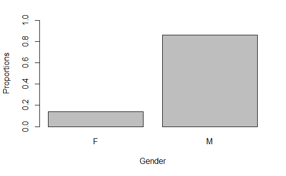

Table 2 shows the frequencies and percents for gender types. There are 14% females and 86% males, which are more than 6 times of females.

*Table 2. Frequencies and percents for each gender in 2012.*

```
  gender_counts_2012 gender_props_2012
F               4725              0.14
M              28838              0.86
```

*Figure 3. Bar plots with proportions of race types in 2012.*

```
        Asian/Pacific Islander                          Black
                   0.013497006                    0.236748801
                      Hispanic Native American/Native Alaskan
                   0.091201621                    0.009236361
                         White
                   0.649316211
```

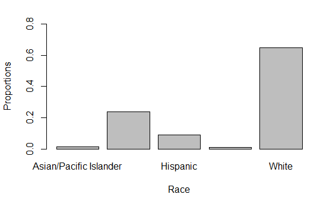

Table 3 shows the frequencies and percents for race types. There are 1% in Asian/Pacific islander, 24% in black, 9% in Hispanic, 1% in native American/native Alaskan and 65% in white.

*Table 3. Frequencies and percents for each race in 2012.*

```
                               race_counts_2012 race_props_2012
Asian/Pacific Islander                      453            0.01
Black                                      7946            0.24
Hispanic                                   3061            0.09
Native American/Native Alaskan              310            0.01
White                                     21793            0.65
```

### Conclusions

I examined the compositions of gun deaths types in American in 2012 and knew the proportions of different groups in terms of gender and race. The most primary intent of gun deaths is suicide and then followed by homicide. The proportion of accidental deaths and undetermined deaths are only 2% and 1% respectively.

As for the individual attributes, there are more males in gun deaths than females. Specifically, 86 percent are males and 14 percent are females. White people have a larger proportions to die from gunshot than other races, i.e., black people, Hispanic, Asian/Pacific islander and native American/native Alaskan in turn. The results are helpful to take measures to decrease the gun deaths rate for different groups.

```r
# 6. Add to your notebook an analysis of the 2019 data by addressing the same
# questions you addressed for 2012.

# read the 2019 data and put it in an object called "gun_2019"
gun_2019 <- read.csv( "full_data_19.csv", header = T, sep = ",")

# calculate the frequencies of different types of gun death in 2019

death_counts_2019 <- table(gun_2019$intent)

# calculate the proportions of different types of gun death in 2019

death_props_2019 <-prop.table(death_counts_2019)

death_props_2019

# provide the bar plot of gun death proportions in 2019

barplot(death_props_2019,
        xlab = "Gun Death",
        ylab = "Proportions",
        ylim = c(0, 0.8))

# calculate the frequencies of different gender types in 2019

gender_counts_2019 <- table(gun_2019$sex)

# calculate the proportions of different gender types in 2019

gender_props_2019 <- prop.table(gender_counts_2019)
gender_props_2019

# provide the bar plot of the gender proportions in 2019

barplot(gender_props_2019,
        xlab = "Gender",
        ylab = "Proportions",
        ylim = c(0, 1))

# calculate the frequencies of different race types in 2019

race_counts_2019 <- table(gun_2019$race)

# calculate the proportions of different race types

race_props_2019 <- prop.table(race_counts_2019)
race_props_2019

# provide the bar plot of the race proportions in 2019

barplot(race_props_2019,
        xlab = "Race",
        ylab = "Proportions",
        ylim = c(0, 0.8))
```

[output not shown]

```r
# 7. For each of the variables of interest, compare proportions for the two
# years (2012 and 2019) with graphs and descriptive statistics.

# combine the full_data.csv and full_data_19.csv as a new file full_data_all.csv
# and read it

gun_all <- read.csv("full_data_all", header = T, sep = ",")


# choose the data from 2012 and 2019

gun_201219 <- subset(gun, gun$year == 2012 || 2019)

# construct a two-way table of frequencies of gun deaths type based on year

ses_death_counts <- table(gun_201219$intent, gun_201219$year)

#construct conditional percentages of gun deaths type

ses_death_prop <- 100 * prop.table(ses_death_counts, 2)
round(ses_death_prop)

# provide a stacked bar plot

barplot(ses_death_prop,
        xlab = "Year",
        ylab = "Percents of gun deaths",
        legend = c("accidental", "homicide", "suicide", "undetermined"),
        args.legend = list(title = "Gun deaths type", cex = .7))
```

[output not shown]

```r
# construct a two-way table of frequencies of gender type based on year

ses_gender_counts <- table(gun_201219$sex, gun_201219$year)

#construct conditional percentages of gun deaths type

ses_gender_prop <- 100 * prop.table(ses_gender_counts, 2)
round(ses_gender_prop)

# provide a stacked bar plot

barplot(ses_gender_prop,
        xlab = "Year",
        ylab = "Percents of gender",
        legend = c("Female", "Male"),
        args.legend = list(title = "Gender", cex = .7))
```

[output not shown]

```r
# construct a two-way table of frequencies of race type based on year

ses_race_counts <- table(gun_201219$race, gun_201219$year)

#construct conditional percentages of race type type

ses_race_prop <- 100 * prop.table(ses_race_counts, 2)
round(ses_race_prop)

# provide a stacked bar plot

barplot(ses_race_prop,
        xlab = "Year",
        ylab = "Percents of race",
        legend = c("Asian/Pacific Islander", "Black", "Hispanic", "Native American/Native Alaskan", "White"),
        args.legend = list(title = "Race", cex = .7))
```

[output not shown]